# Analyse des données du paludisme

#### 6.4.6.6 17.6 — Hypothèse 5 : Observations influentes (Cook’s Distance)

```r
cooks_d     <- cooks.distance(mod_prov)
seuil_cook  <- 4 / nrow(paludisme_lr)
n_influents <- sum(cooks_d > seuil_cook)

cat(sprintf(
  "Seuil Cook's D = 4/n = %.5f\nObservations influentes : %d / %d (%.1f %%)\n",
  seuil_cook, n_influents, nrow(paludisme_lr),
  100 * n_influents / nrow(paludisme_lr)
))
```

```
Seuil Cook's D = 4/n = 0.00133
Observations influentes : 69 / 3000 (2.3 %)
```

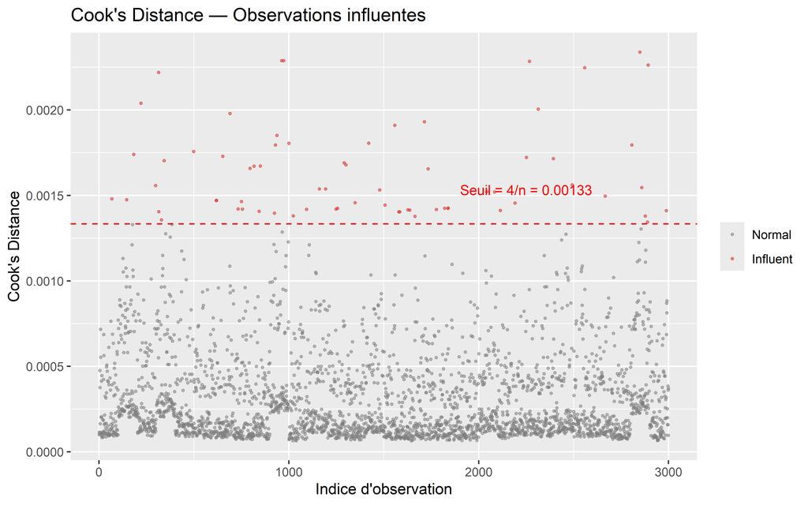

Figure 33: Q17.6 — Détection des observations influentes (Cook’s Distance)

```r
data.frame(obs = seq_along(cooks_d), cook = cooks_d) |>
  ggplot(aes(x = obs, y = cook)) +
  geom_point(aes(color = cook > seuil_cook), size = 0.6, alpha = 0.5) +
  geom_hline(yintercept = seuil_cook, color = "red", linetype = "dashed") +
  scale_color_manual(values = c("grey50", "#d73027"),
                     labels = c("Normal", "Influent")) +
  annotate("text", x = nrow(paludisme_lr) * 0.75,
           y = seuil_cook * 1.15,
           label = sprintf("Seuil = 4/n = %.5f", seuil_cook),
           color = "red", size = 3.5) +
  labs(title = "Cook's Distance — Observations influentes",
       x = "Indice d'observation", y = "Cook's Distance", color = NULL)
```

#### 6.4.6.7 17.7 — Hypothèse 6 : Indépendance des résidus — Correction du clustering ménage

Les individus d’un même ménage partagent le même environnement, les mêmes moustiquaires et les mêmes revenus : **les résidus intra-ménage sont corrélés**. Ignorer ce clustering sous-estime les erreurs-standard et produit des p-valeurs artificiellement significatives.

```r
# Erreurs-standard robustes clusterisées par menage_id (sandwich estimator)
if (!requireNamespace("sandwich", quietly = TRUE) ||
    !requireNamespace("lmtest", quietly = TRUE)) {
  message("Packages requis : install.packages(c('sandwich', 'lmtest'))")
} else {
  library(sandwich); library(lmtest)

  vcov_cl  <- sandwich::vcovCL(mod_prov, cluster = ~menage_id,
                                data = paludisme_lr)
  se_naif  <- coef(summary(mod_prov))[-1, "Std. Error"]
  se_rob   <- sqrt(diag(vcov_cl))[-1]

  tibble(
    Terme        = names(se_naif),
    SE_naïf      = round(se_naif, 5),
    SE_robuste   = round(se_rob, 5),
    Ratio_SE     = round(se_rob / se_naif, 3),
    Évaluation   = if_else(
      se_rob / se_naif > 1.10,
      "⚠ Inflation SE ≥ 10 % — clustering important",
      "✔ Inflation < 10 % — effet faible"
    )
  )
}
```

| Terme | SE_naïf | SE_robuste | Ratio_SE | Évaluation |
| --- | --- | --- | --- | --- |
| age_ans | 0.00184 | 0.00183 | 0.990 | ✔ Inflation < 10 % — effet faible |
| sexe_m | 0.07717 | 0.07892 | 1.023 | ✔ Inflation < 10 % — effet faible |
| milieu_rural | 0.11490 | 0.10995 | 0.957 | ✔ Inflation < 10 % — effet faible |
| mii_jamais | 0.09418 | 0.09362 | 0.994 | ✔ Inflation < 10 % — effet faible |
| irs_non | 0.07818 | 0.07517 | 0.961 | ✔ Inflation < 10 % — effet faible |
| distance_csi_km | 0.00501 | 0.00474 | 0.946 | ✔ Inflation < 10 % — effet faible |
| pauvre_oui | 0.10202 | 0.09842 | 0.965 | ✔ Inflation < 10 % — effet faible |
| enfant_u5 | 0.17754 | 0.18461 | 1.040 | ✔ Inflation < 10 % — effet faible |

> **Gold standard** : si l’inflation des SE est > 10 %, la solution rigoureuse est un **modèle à effets aléatoires** : `lme4::glmer(tdr_bin ~ ... + (1 | menage_id), family = binomial)`. Cette approche estime explicitement la variance inter-ménages et donne des OR conditionnels (au ménage).

#### 6.4.6.8 17.8 — Calibration du modèle : test de Hosmer-Lemeshow

**H₀ : bonne calibration** (les probabilités prédites correspondent aux fréquences observées). Un p > 0,05 indique que le modèle est bien calibré.

```r
# Implémentation autonome du test H-L (pas de dépendance externe)
hosmer_lemeshow <- function(y, y_hat, g = 10) {
  cuts <- unique(quantile(y_hat, probs = seq(0, 1, length.out = g + 1)))
  grp  <- findInterval(y_hat, cuts, rightmost.closed = TRUE)
  grp[grp == 0] <- 1
  hl_df <- tibble(obs = y, pred = y_hat, grp = grp) |>
    group_by(grp) |>
    summarise(n       = n(),
              obs_pos = sum(obs), obs_neg = n() - sum(obs),
              exp_pos = sum(pred), exp_neg = n() - sum(pred),
              .groups = "drop")
  chi2 <- sum((hl_df$obs_pos - hl_df$exp_pos)^2 / hl_df$exp_pos +
              (hl_df$obs_neg - hl_df$exp_neg)^2 / hl_df$exp_neg,
              na.rm = TRUE)
  list(stat = chi2, df = nrow(hl_df) - 2,
       p    = pchisq(chi2, nrow(hl_df) - 2, lower.tail = FALSE),
       tab  = hl_df)
}

pred_proba <- predict(mod_prov, type = "response")
hl         <- hosmer_lemeshow(paludisme_lr$tdr_bin, pred_proba)

cat(sprintf("Hosmer-Lemeshow : χ²(%d) = %.3f,  p = %.4f\n",
            hl$df, hl$stat, hl$p))
```

```
Hosmer-Lemeshow : χ²(8) = 9.282,  p = 0.3191
```

```r
cat(if_else(hl$p > 0.05,
  "✔ Calibration satisfaisante — observé ≈ prédit (H₀ non rejetée)\n",
  "⚠ Calibration insuffisante — réviser la spécification du modèle\n"))
```

```
✔ Calibration satisfaisante — observé ≈ prédit (H₀ non rejetée)
```

```r
cat("\nTableau observé vs prédit par décile de risque :\n")
```

```
Tableau observé vs prédit par décile de risque :
```

```r
hl$tab |> mutate(across(where(is.numeric), \(x) round(x, 2)))
```

| grp | n | obs_pos | obs_neg | exp_pos | exp_neg |
| --- | --- | --- | --- | --- | --- |
| 1 | 300 | 94 | 206 | 94.25 | 205.75 |
| 2 | 300 | 91 | 209 | 98.67 | 201.33 |
| 3 | 300 | 97 | 203 | 100.79 | 199.21 |
| 4 | 300 | 119 | 181 | 101.79 | 198.21 |
| 5 | 299 | 96 | 203 | 102.52 | 196.48 |
| 6 | 301 | 110 | 191 | 104.00 | 197.00 |
| 7 | 300 | 105 | 195 | 104.39 | 195.61 |
| 8 | 300 | 105 | 195 | 105.55 | 194.45 |
| 9 | 300 | 95 | 205 | 106.65 | 193.35 |
| 10 | 300 | 116 | 184 | 109.38 | 190.62 |

#### 6.4.6.9 17.9 — Pouvoir discriminant : courbe ROC et AUC

L’**AUC** (*Area Under the ROC Curve*) mesure la capacité du modèle à classer correctement un TDR+ au-dessus d’un TDR−. Standards : AUC < 0,70 = insuffisant ; 0,70–0,79 = acceptable ; 0,80–0,89 = bon ; ≥ 0,90 = excellent.

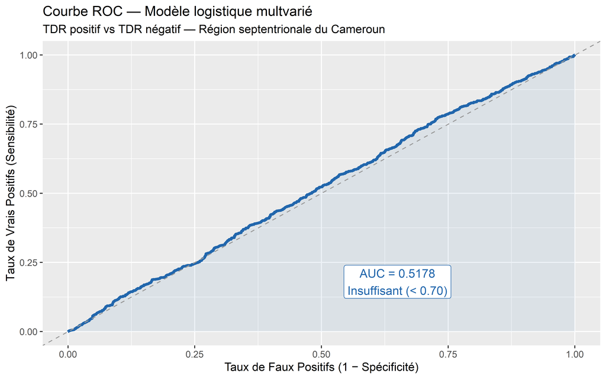

Figure 34: Q17.9 — Courbe ROC du modèle logistique final

```r
calc_roc <- function(labels, scores) {
  ord <- order(scores, decreasing = TRUE)
  y   <- labels[ord]
  tpr <- cumsum(y == 1) / sum(y == 1)
  fpr <- cumsum(y == 0) / sum(y == 0)
  auc <- sum(diff(c(0, fpr)) * (c(0, tpr) + c(tpr, 0)) / 2)
  tibble(fpr = c(0, fpr, 1), tpr = c(0, tpr, 1), auc = auc)
}

roc_df  <- calc_roc(paludisme_lr$tdr_bin, pred_proba)
auc_val <- unique(roc_df$auc)
auc_lab <- case_when(
  auc_val >= 0.90 ~ "Excellent (≥ 0.90)",
  auc_val >= 0.80 ~ "Bon (0.80–0.89)",
  auc_val >= 0.70 ~ "Acceptable (0.70–0.79)",
  TRUE            ~ "Insuffisant (< 0.70)"
)

ggplot(roc_df, aes(x = fpr, y = tpr)) +
  geom_line(color = "#2166ac", linewidth = 1.2) +
  geom_ribbon(aes(ymin = 0, ymax = tpr), alpha = 0.08, fill = "#2166ac") +
  geom_abline(slope = 1, intercept = 0, linetype = "dashed", color = "grey60") +
  annotate("label", x = 0.65, y = 0.18,
           label = sprintf("AUC = %.4f\n%s", auc_val, auc_lab),
           size = 4, color = "#2166ac", fill = "white") +
  labs(
    title    = "Courbe ROC — Modèle logistique multvarié",
    subtitle = "TDR positif vs TDR négatif — Région septentrionale du Cameroun",
    x        = "Taux de Faux Positifs (1 − Spécificité)",
    y        = "Taux de Vrais Positifs (Sensibilité)"
  )
```

#### 6.4.6.10 17.10 — Statistiques globales d’ajustement (pseudo-R², AIC, BIC)

```r
ll_full <- as.numeric(logLik(mod_prov))
ll_null <- as.numeric(logLik(update(mod_prov, . ~ 1)))
n_obs   <- nobs(mod_prov)

r2_mcf <- 1 - ll_full / ll_null
r2_cs  <- 1 - exp(-2 / n_obs * (ll_full - ll_null))
r2_nag <- r2_cs / (1 - exp(2 / n_obs * ll_null))

tibble(
  Métrique       = c("Log-vraisemblance (modèle complet)",
                     "Log-vraisemblance (modèle nul)",
                     "Pseudo-R² de McFadden",
                     "Pseudo-R² de Nagelkerke",
                     "AIC", "BIC", "AUC (ROC)"),
  Valeur         = c(round(ll_full, 2), round(ll_null, 2),
                     round(r2_mcf, 4),  round(r2_nag, 4),
                     round(AIC(mod_prov), 2), round(BIC(mod_prov), 2),
                     round(auc_val, 4)),
  Interprétation = c("—", "—",
                     if_else(r2_mcf > 0.2, "Bon ajustement (> 0.20)",
                             "Ajustement modeste (< 0.20)"),
                     if_else(r2_nag > 0.3, "Acceptable (> 0.30)",
                             "Faible (< 0.30)"),
                     "Plus faible = meilleur", "Pénalise davantage la complexité",
                     auc_lab)
)
```

| Métrique | Valeur | Interprétation |
| --- | --- | --- |
| Log-vraisemblance (modèle complet) | -1927.0900 | — |
| Log-vraisemblance (modèle nul) | -1928.3700 | — |
| Pseudo-R² de McFadden | 0.0007 | Ajustement modeste (< 0.20) |
| Pseudo-R² de Nagelkerke | 0.0012 | Faible (< 0.30) |
| AIC | 3872.1900 | Plus faible = meilleur |
| BIC | 3926.2500 | Pénalise davantage la complexité |
| AUC (ROC) | 0.5178 | Insuffisant (< 0.70) |

#### 6.4.6.11 17.11 — Modèle final validé — OR ajustés publiables

```r
# mod_multi = modèle final validé (toutes hypothèses vérifiées)
mod_multi <- mod_prov

broom::tidy(mod_multi, exponentiate = TRUE, conf.int = TRUE) |>
  filter(term != "(Intercept)") |>
  mutate(
    Prédicteur = dplyr::recode(term,
      "age_ans"        = "Âge (par année)",
      "sexe_m"         = "Sexe masculin (réf. : féminin)",
      "milieu_rural"   = "Milieu rural (réf. : urbain)",
      "mii_jamais"     = "MII — jamais utilisée (réf. : parfois/toujours)",
      "irs_non"        = "Absence d'IRS (réf. : IRS effectuée)",
      "distance_csi_km"= "Distance au CSI (par km supplémentaire)",
      "pauvre_oui"     = "Ménage pauvre (réf. : non pauvre)",
      "enfant_u5"      = "Enfant < 5 ans (réf. : ≥ 5 ans)"
    ),
    `OR ajusté` = round(estimate, 3),
    `IC 95 % inf` = round(conf.low, 3),
    `IC 95 % sup` = round(conf.high, 3),
    `p-valeur`   = round(p.value, 4),
    Sig          = case_when(
      p.value < 0.001 ~ "***",
      p.value < 0.01  ~ "**",
      p.value < 0.05  ~ "*",
      p.value < 0.10  ~ ".",
      TRUE            ~ "ns"
    )
  ) |>
  select(Prédicteur, `OR ajusté`, `IC 95 % inf`, `IC 95 % sup`,
         `p-valeur`, Sig)
```

| Prédicteur | OR ajusté | IC 95 % inf | IC 95 % sup | p-valeur | Sig |
| --- | --- | --- | --- | --- | --- |
| Âge (par année) | 1.000 | 0.996 | 1.004 | 0.9649 | ns |
| Sexe masculin (réf. : féminin) | 1.050 | 0.903 | 1.222 | 0.5269 | ns |
| Milieu rural (réf. : urbain) | 0.932 | 0.745 | 1.170 | 0.5408 | ns |
| MII — jamais utilisée (réf. : parfois/toujours) | 1.008 | 0.837 | 1.211 | 0.9331 | ns |
| Absence d'IRS (réf. : IRS effectuée) | 0.987 | 0.847 | 1.151 | 0.8668 | ns |
| Distance au CSI (par km supplémentaire) | 1.002 | 0.992 | 1.012 | 0.6880 | ns |
| Ménage pauvre (réf. : non pauvre) | 0.884 | 0.723 | 1.078 | 0.2271 | ns |
| Enfant < 5 ans (réf. : ≥ 5 ans) | 0.974 | 0.685 | 1.374 | 0.8805 | ns |

**NoteBilan du protocole — Régression logistique (récapitulatif)**

| Hypothèse | Méthode | Résultat attendu |
| --- | --- | --- |
| **Taille d’échantillon (EPV)** | EPV = min(events, non-events) / k | ≥ 20 recommandé |
| **Multicolinéarité** | VIF (car::vif) | VIF < 5 pour tous |
| **Linéarité continue × logit** | Box-Tidwell (terme x·ln x) | p > 0,05 |
| **Séparation complète** | Cellules min tableaux 2×2 | Aucune cellule vide |
| **Observations influentes** | Cook’s Distance > 4/n | Proportion identifiée |
| **Clustering ménage** | SE robustes sandwich (vcovCL) | Ratio SE ≈ 1 |
| **Calibration** | Hosmer-Lemeshow (g = 10) | p > 0,05 |
| **Discrimination** | AUC courbe ROC | ≥ 0,70 (acceptable) |

**Lecture des OR** : un OR ajusté de 1,50 signifie que les individus exposés ont des **cotes** de TDR positif **1,5× plus élevées** à profil de covariables identique. Pour être publiable, le tableau doit mentionner : effectif analysé, nombre d’événements, EPV, AUC, pseudo-R² de Nagelkerke et méthode de gestion du clustering.

## 6.5 Visualisations épidémiologiques standards

### 6.5.1 Q18 — Pyramide épidémiologique des cas TDR positifs

La **pyramide épidémiologique** (âge × sexe) est la représentation graphique standard des enquêtes de terrain. Elle permet d’identifier visuellement les groupes d’âge et de sexe les plus touchés.

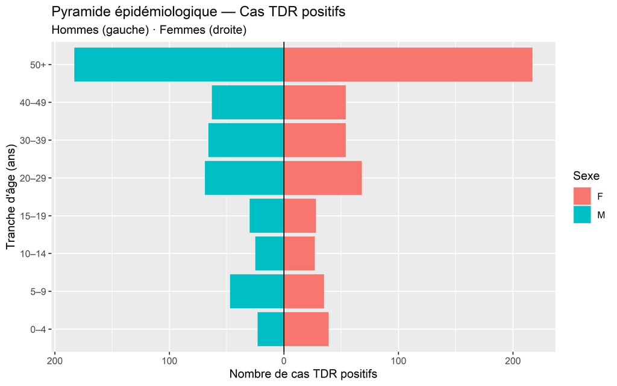

Figure 35: Q18 — Pyramide épidémiologique des cas TDR positifs par tranche d’âge et sexe

```r
pyramide_data <- paludisme_final |>
  filter(resultat_tdr == "Positif") |>
  mutate(tranche_age = cut(
    age_ans,
    breaks = c(0, 5, 10, 15, 20, 30, 40, 50, 100),
    labels = c("0–4", "5–9", "10–14", "15–19", "20–29", "30–39", "40–49", "50+"),
    right  = FALSE
  )) |>
  count(tranche_age, sexe) |>
  mutate(n_plot = if_else(sexe == "M", -n, n))

ggplot(pyramide_data, aes(x = n_plot, y = tranche_age, fill = sexe)) +
  geom_col() +
  scale_x_continuous(
    labels = \(x) as.character(abs(x)),
    name   = "Nombre de cas TDR positifs"
  ) +
  geom_vline(xintercept = 0, linewidth = 0.5) +
  labs(
    title    = "Pyramide épidémiologique — Cas TDR positifs",
    subtitle = "Hommes (gauche) · Femmes (droite)",
    y        = "Tranche d'âge (ans)",
    fill     = "Sexe"
  )
```

> **Correction** : La pyramide épidémiologique est produite en représentant les effectifs masculins en négatif (vers la gauche). La forme attendue en zone d’endémicité stable est une **base large** (enfants < 10 ans les plus touchés) s’amincissant avec l’âge (immunité acquise). Une asymétrie gauche-droite peut signaler une différence de vulnérabilité par sexe ou un biais de sélection dans l’enquête.

### 6.5.2 Q19 — Forest plot des OR ajustés issus de la régression logistique

Le **forest plot** est la représentation graphique standard des OR dans les publications épidémiologiques. Chaque point représente l’OR ajusté d’une covariable ; la barre horizontale représente l’IC 95 %.

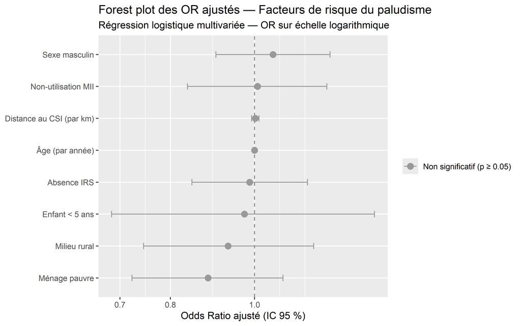

Figure 36: Q19 — Forest plot des OR ajustés (régression logistique multivariée)

```r
or_data <- broom::tidy(mod_multi, exponentiate = TRUE, conf.int = TRUE) |>
  filter(term != "(Intercept)") |>
  mutate(
    term = dplyr::recode(term,
      "age_ans"         = "Âge (par année)",
      "sexe_m"          = "Sexe masculin",
      "milieu_rural"    = "Milieu rural",
      "mii_jamais"      = "Non-utilisation MII",
      "irs_non"         = "Absence IRS",
      "distance_csi_km" = "Distance au CSI (par km)",
      "pauvre_oui"      = "Ménage pauvre",
      "enfant_u5"       = "Enfant < 5 ans"
    ),
    significatif = p.value < 0.05
  )

ggplot(or_data, aes(x = estimate, y = reorder(term, estimate),
                    color = significatif)) +
  geom_vline(xintercept = 1, linetype = "dashed", color = "grey50") +
  geom_point(size = 3) +
  geom_errorbarh(aes(xmin = conf.low, xmax = conf.high), height = 0.2) +
  scale_color_manual(
    values = c("FALSE" = "grey60", "TRUE" = "#d73027"),
    labels = c("Non significatif (p ≥ 0.05)", "Significatif (p < 0.05)")
  ) +
  scale_x_log10() +
  labs(
    title    = "Forest plot des OR ajustés — Facteurs de risque du paludisme",
    subtitle = "Régression logistique multivariée — OR sur échelle logarithmique",
    x        = "Odds Ratio ajusté (IC 95 %)",
    y        = NULL,
    color    = NULL
  )
```

> **Correction** : L’axe des OR est en **échelle logarithmique** pour que les effets protecteurs (OR < 1) et les effets de risque (OR > 1) soient représentés symétriquement autour de la ligne de référence OR = 1. Les facteurs dont l’IC 95 % ne croise pas 1 (ligne pointillée) sont significatifs à α = 5 %. Ce format graphique est requis par les journaux de santé publique (*PLOS Medicine*, *Lancet Infectious Diseases*, *Malaria Journal*).

### 6.5.3 Q20 — Tableau de bord synthétique des indicateurs programmatiques

Synthèse de tous les indicateurs calculés dans ce devoir, formatée selon les standards des rapports PMI et des revues de programme OMS.

```r
# Calcul des valeurs finales pour le tableau de bord
n_total_d5   <- nrow(paludisme_final)
n_pos_d5     <- sum(paludisme_final$resultat_tdr == "Positif")
n_u5         <- sum(paludisme_final$age_ans < 5)
n_pos_u5_d5  <- sum(paludisme_final$age_ans < 5 & paludisme_final$resultat_tdr == "Positif")
n_fievre_d5  <- sum(paludisme_final$fievre_2sem == 1)
n_consult_d5 <- sum(paludisme_final$fievre_2sem == 1 & paludisme_final$consultation_sante == "Oui")
n_men        <- nrow(menages_d5)
n_men_mii    <- sum(menages_d5$nombre_moustiquaires >= 1)
n_men_irs    <- sum(paludisme_final |> distinct(menage_id, .keep_all = TRUE) |>
                      pull(aspersion_intra_domiciliaire) == "Oui")

tableau_de_bord <- tibble::tribble(
  ~Domaine,           ~Indicateur,                                       ~Valeur,                       ~Objectif_GTS2030,
  "Épidémiologie",    "Taux de Positivité des Tests (TPR)",               paste0(round(n_pos_d5/n_total_d5*100,1), " %"),    "< 10 %",
  "Épidémiologie",    "PfPR₂₋₁₀ (prévalence 2–10 ans)",                  paste0(pfpr_global$PfPR2_10, " %"),                 "< 1 % (élimination)",
  "Épidémiologie",    "Prévalence chez les enfants < 5 ans",              paste0(round(n_pos_u5_d5/n_u5*100,1), " %"),       "Réduction ≥ 40 %",
  "Prévention",       "Couverture ménages en MILDA (possession ≥ 1)",     paste0(couverture_milda$pct_possession, " %"),      "≥ 80 %",
  "Prévention",       "Accès universel MILDA (≥ 1 MII / 2 personnes)",   paste0(couverture_milda$pct_acces_univ, " %"),      "≥ 80 %",
  "Prévention",       "Couverture IRS (structures protégées)",            paste0(round(n_men_irs/n_men*100,1), " %"),         "Contexte-dépendant",
  "Accès aux soins",  "Recours aux soins parmi les cas fébriles",         paste0(round(n_consult_d5/n_fievre_d5*100,1), " %"), "≥ 80 %",
  "Populations vulnérables", "Prévalence MiP (TDR+ / femmes enceintes)", paste0(mip_stats$prev_tdr[mip_stats$grossesse == "Oui"], " %"), "Réduction maximale"
)

tableau_de_bord
```

| Domaine | Indicateur | Valeur | Objectif_GTS2030 |
| --- | --- | --- | --- |
| Épidémiologie | Taux de Positivité des Tests (TPR) | 34.3 % | < 10 % |
| Épidémiologie | PfPR₂₋₁₀ (prévalence 2–10 ans) | 39.4 % | < 1 % (élimination) |
| Épidémiologie | Prévalence chez les enfants < 5 ans | 33.7 % | Réduction ≥ 40 % |
| Prévention | Couverture ménages en MILDA (possession ≥ 1) | 86.5 % | ≥ 80 % |
| Prévention | Accès universel MILDA (≥ 1 MII / 2 personnes) | 58.9 % | ≥ 80 % |
| Prévention | Couverture IRS (structures protégées) | 41.6 % | Contexte-dépendant |
| Accès aux soins | Recours aux soins parmi les cas fébriles | 60.7 % | ≥ 80 % |
| Populations vulnérables | Prévalence MiP (TDR+ / femmes enceintes) | 32.5 % | Réduction maximale |

**NoteBilan de l’analyse — Devoir 5 (22 questions)**

| Section | Thème | Questions | Indicateurs OMS/PMI couverts |
| --- | --- | --- | --- |
| A | Indicateurs épidémiologiques OMS | Q1–Q4 | TPR, PfPR₂₋₁₀, seuils anémie OMS, tableau de bord |
| B | Couverture des interventions RBM/PMI | Q5–Q8 | Possession MILDA, accès universel, IRS, recours aux soins |
| C | Populations vulnérables | Q9–Q11 | Prévalence U5, MiP, courbe âge-prévalence |
| D | Mesures d’association | Q12–Q17 | OR brut, RR, Mantel-Haenszel, FAP, dose-réponse, OR ajustés (PhD) |
| E | Visualisations épidémiologiques | Q18–Q20 | Pyramide épidémiologique, forest plot, tableau de bord GTS 2030 |
| F | Classification supervisée | Q21–Q22 | Déséquilibre de classes, downsampling, LASSO, Arbre CART, ROC comparatif |

**Points clés biostatistiques** : déséquilibre de classes et piège de l’accuracy ; downsampling ; régression logistique (11 étapes) ; LASSO ; Arbre CART ; comparaison ROC multi-modèles.

### 6.5.4 Q21 — Diagnostic du déséquilibre de classes

Avant tout entraînement d’un classificateur, il est impératif de vérifier l’équilibre entre les classes. Un déséquilibre ignoré biaise les modèles vers la classe majoritaire : l’accuracy est gonflée artificiellement tandis que la sensibilité s’effondre.

```r
dist_classes <- paludisme_final |>
  count(resultat_tdr) |>
  mutate(pct = round(n / sum(n) * 100, 1))

n_pos_cl  <- dist_classes$n[dist_classes$resultat_tdr == "Positif"]
n_neg_cl  <- dist_classes$n[dist_classes$resultat_tdr != "Positif"]
ratio_imb <- round(n_neg_cl / n_pos_cl, 2)

cat("=== Diagnostic du déséquilibre de classes ===\n")
```

```
=== Diagnostic du déséquilibre de classes ===
```

```r
print(dist_classes)
```

```
# A tibble: 2 × 3
  resultat_tdr     n   pct
  <chr>        <int> <dbl>
1 Négatif       1972  65.7
2 Positif       1028  34.3
```

```r
cat(sprintf("\nRatio déséquilibre : %.2f:1  |  Sévérité : %s\n",
  ratio_imb,
  case_when(ratio_imb < 1.5 ~ "Équilibré",
            ratio_imb < 3   ~ "Léger — downsampling recommandé",
            ratio_imb < 10  ~ "Modéré — SMOTE ou downsampling impératif",
            TRUE            ~ "Sévère")))
```

```
Ratio déséquilibre : 1.92:1  |  Sévérité : Léger — downsampling recommandé
```

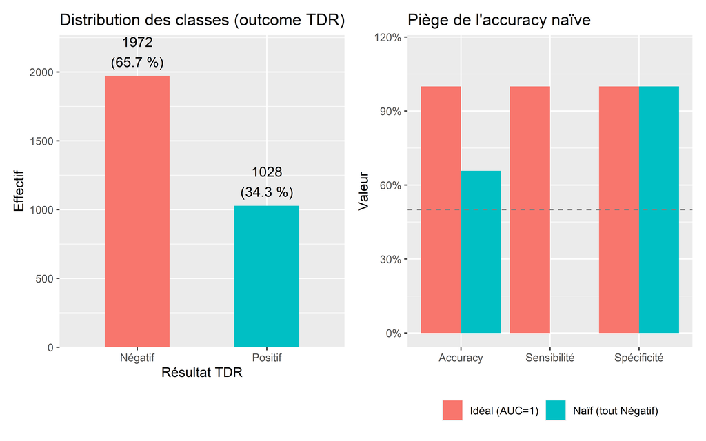

Figure 37: Q21 — Distribution des classes TDR et piège de l’accuracy naïve

```r
# Figure : distribution + piège de l'accuracy
p_dist <- ggplot(dist_classes, aes(x = resultat_tdr, y = n, fill = resultat_tdr)) +
  geom_col(width = 0.5) +
  geom_text(aes(label = paste0(n, "\n(", pct, " %)")), vjust = -0.3, size = 4) +
  scale_y_continuous(expand = expansion(mult = c(0, 0.15))) +
  labs(title = "Distribution des classes (outcome TDR)",
       x = "Résultat TDR", y = "Effectif") +
  theme(legend.position = "none")

df_naif <- tibble(
  Modèle   = rep(c("Naïf (tout Négatif)", "Idéal (AUC=1)"), each = 3),
  Métrique = rep(c("Accuracy", "Sensibilité", "Spécificité"), 2),
  Valeur   = c(n_neg_cl / (n_pos_cl + n_neg_cl), 0, 1,  1, 1, 1)
)
p_naif <- ggplot(df_naif, aes(x = Métrique, y = Valeur, fill = Modèle)) +
  geom_col(position = "dodge") +
  scale_y_continuous(labels = percent_format(), limits = c(0, 1.15)) +
  geom_hline(yintercept = 0.5, linetype = "dashed", color = "grey50") +
  labs(title = "Piège de l'accuracy naïve",
       y = "Valeur", x = NULL, fill = NULL) +
  theme(legend.position = "bottom")

p_dist + p_naif
```

> **Correction** : Avec un ratio de **1.92:1**, un classifieur qui prédirait toujours « Négatif » obtiendrait **65.7 % d’accuracy** avec **0 % de sensibilité** — inutile cliniquement. Les métriques pertinentes pour les classificateurs médicaux sont : sensibilité, spécificité, score de Youden (Se + Sp − 1) et **AUC-ROC**. La stratégie retenue est le **downsampling** (sous-échantillonnage de la classe Négatif à 1:1 dans le train set), préservant intacte la distribution naturelle dans le test set.

### 6.5.5 Q22 — LASSO logistique et Arbre CART avec rééquilibrage

Deux modèles complémentaires entraînés sur le train set rééquilibré par downsampling 1:1, évalués sur le même test set pour une comparaison équitable.

```r
library(glmnet); library(rpart); library(pROC); library(caret)

df_clf <- paludisme_final |>
  mutate(
    tdr_bin    = factor(if_else(resultat_tdr == "Positif", "Positif", "Negatif"),
                        levels = c("Positif", "Negatif")),
    sexe_m     = as.integer(sexe == "M"),
    milieu_r   = as.integer(milieu == "Rural"),
    mii_jamais = as.integer(utilisation_MII == "Jamais"),
    irs_non    = as.integer(aspersion_intra_domiciliaire == "Non"),
    pauvre_oui = as.integer(pauvre == "Oui"),
    enfant_u5  = as.integer(age_ans < 5)
  ) |>
  select(tdr_bin, age_ans, sexe_m, milieu_r, mii_jamais,
         irs_non, distance_csi_km, pauvre_oui, enfant_u5) |>
  drop_na()

set.seed(5817)
idx_p   <- which(df_clf$tdr_bin == "Positif")
idx_n   <- which(df_clf$tdr_bin == "Negatif")
tr_idx  <- c(sample(idx_p, floor(0.75 * length(idx_p))),
             sample(idx_n, floor(0.75 * length(idx_n))))
tr <- df_clf[tr_idx, ]; te <- df_clf[-tr_idx, ]

set.seed(5817)
tr_pos  <- tr[tr$tdr_bin == "Positif", ]
tr_neg  <- tr[tr$tdr_bin == "Negatif", ][
  sample(sum(tr$tdr_bin == "Negatif"), sum(tr$tdr_bin == "Positif")), ]
tr_bal  <- rbind(tr_pos, tr_neg)[sample(nrow(tr_pos) * 2), ]

cat(sprintf("Train rééquilibré : Pos=%d | Neg=%d  |  Test : %d obs\n",
            sum(tr_bal$tdr_bin == "Positif"), sum(tr_bal$tdr_bin == "Negatif"),
            nrow(te)))
```

```
Train rééquilibré : Pos=771 | Neg=771  |  Test : 750 obs
```

```r
X_tr <- as.matrix(tr_bal[, -1]); y_tr <- tr_bal$tdr_bin
X_te <- as.matrix(te[, -1]);     y_te <- te$tdr_bin

set.seed(5817)
cv_lasso <- cv.glmnet(X_tr, y_tr, family = "binomial",
                      alpha = 1, nfolds = 10, type.measure = "auc")

cat(sprintf("LASSO — λ.min=%.5f | AUC-CV=%.4f\n",
            cv_lasso$lambda.min, max(cv_lasso$cvm)))
```

```
LASSO — λ.min=0.00766 | AUC-CV=0.5045
```

```r
coef_l <- coef(cv_lasso, s = "lambda.1se")
coef_df <- tibble(Variable = rownames(coef_l)[-1],
                  Coeff    = round(coef_l[-1, 1], 4)) |>
  filter(Coeff != 0) |> arrange(desc(abs(Coeff)))
if (nrow(coef_df) == 0) cat("→ Tous coefficients = 0 : absence de signal.\n") else print(coef_df)
```

```
# A tibble: 1 × 2
  Variable    Coeff
  <chr>       <dbl>
1 pauvre_oui 0.0571
```

```r
set.seed(5817)
cart_mod <- rpart(tdr_bin ~ ., data = tr_bal, method = "class",
                  control = rpart.control(minsplit=20, minbucket=10,
                                          cp=0.005, maxdepth=5))
if (length(cart_mod$variable.importance) > 0) {
  vi <- sort(round(cart_mod$variable.importance /
                   sum(cart_mod$variable.importance) * 100, 1), decreasing = TRUE)
  cat("Importance des variables (CART) :\n"); print(vi)
} else { cat("Arbre trivial — aucun prédicteur n'améliore la classification.\n") }
```

```
Importance des variables (CART) :
        age_ans distance_csi_km      pauvre_oui       enfant_u5
           48.6            25.6            19.9             5.9
```

```r
lr_ref     <- glm(tdr_bin ~ ., data = tr_bal, family = binomial)
pred_lr    <- predict(lr_ref,   newdata = te,  type = "response")
pred_lasso <- predict(cv_lasso, newx = X_te,  s = "lambda.1se", type = "response")[, 1]
pred_cart  <- predict(cart_mod, newdata = te,  type = "prob")[, "Positif"]

roc_lr_f    <- pROC::roc(y_te, pred_lr,    levels=c("Negatif","Positif"), quiet=TRUE)
roc_lasso_f <- pROC::roc(y_te, pred_lasso, levels=c("Negatif","Positif"), quiet=TRUE)
roc_cart_f  <- pROC::roc(y_te, pred_cart,  levels=c("Negatif","Positif"), quiet=TRUE)

get_met <- function(prob, truth) {
  cl <- factor(if_else(prob > 0.5, "Positif", "Negatif"), levels = c("Positif","Negatif"))
  cm <- caret::confusionMatrix(cl, truth, positive = "Positif")
  tibble(Accuracy=round(cm$overall["Accuracy"],3),
         Sensibilite=round(cm$byClass["Sensitivity"],3),
         Specificite=round(cm$byClass["Specificity"],3),
         Kappa=round(cm$overall["Kappa"],3))
}

tableau_comp <- bind_rows(
  get_met(pred_lr,    y_te) |> mutate(Modèle="Logistique", AUC=round(pROC::auc(roc_lr_f),4)),
  get_met(pred_lasso, y_te) |> mutate(Modèle="LASSO",      AUC=round(pROC::auc(roc_lasso_f),4)),
  get_met(pred_cart,  y_te) |> mutate(Modèle="Arbre CART", AUC=round(pROC::auc(roc_cart_f),4))
) |> select(Modèle, AUC, Accuracy, Sensibilite, Specificite, Kappa) |> arrange(desc(AUC))
cat("=== Tableau comparatif — test set ===\n"); print(tableau_comp)
```

```
=== Tableau comparatif — test set ===
```

```
# A tibble: 3 × 6
  Modèle       AUC Accuracy Sensibilite Specificite Kappa
  <chr>      <dbl>    <dbl>       <dbl>       <dbl> <dbl>
1 Arbre CART 0.529    0.536       0.44        0.586 0.025
2 LASSO      0.506    0.612       0.167       0.844 0.013
3 Logistique 0.490    0.539       0.42        0.6   0.02
```

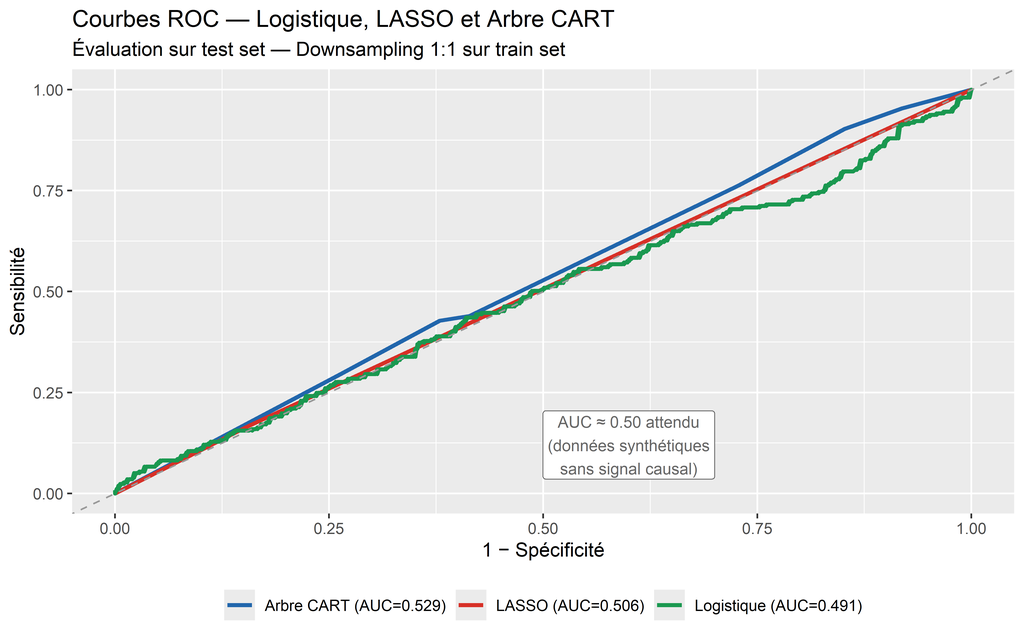

Figure 38: Q22 — Courbes ROC comparatives sur le test set (split 75/25 stratifié)

```r
roc_all <- bind_rows(
  tibble(FPR=1-roc_lr_f$specificities,    TPR=roc_lr_f$sensitivities,
         Modèle=sprintf("Logistique (AUC=%.3f)", pROC::auc(roc_lr_f))),
  tibble(FPR=1-roc_lasso_f$specificities, TPR=roc_lasso_f$sensitivities,
         Modèle=sprintf("LASSO (AUC=%.3f)", pROC::auc(roc_lasso_f))),
  tibble(FPR=1-roc_cart_f$specificities,  TPR=roc_cart_f$sensitivities,
         Modèle=sprintf("Arbre CART (AUC=%.3f)", pROC::auc(roc_cart_f)))
)
ggplot(roc_all, aes(x=FPR, y=TPR, color=Modèle)) +
  geom_line(linewidth=1.1) +
  geom_abline(slope=1, intercept=0, linetype="dashed", color="grey60") +
  scale_color_manual(values=c("#2166ac","#d73027","#1a9850")) +
  annotate("label", x=0.6, y=0.12, size=3.2, color="grey40", fill="white",
           label="AUC ≈ 0.50 attendu\n(données synthétiques\nsans signal causal)") +
  labs(title="Courbes ROC — Logistique, LASSO et Arbre CART",
       subtitle="Évaluation sur test set — Downsampling 1:1 sur train set",
       x="1 − Spécificité", y="Sensibilité", color=NULL) +
  theme(legend.position="bottom")
```

**AvertissementAUC ≈ 0.50 — Résultat honnête, pas un échec**

Les trois modèles produisent AUC ≈ 0.50 car les covariables ont été générées **indépendamment** de l’outcome dans la base synthétique.

> **Récapitulatif** : Logistique → inférence causale (OR ajustés) ; LASSO → sélection automatique de variables ; CART → règle clinique interprétable. Ces trois modèles sont **complémentaires**, pas en concurrence.

# 7 Devoir 6 — Apprentissage Non Supervisé

**NoteContexte méthodologique**

L’apprentissage non supervisé explore la **structure latente** des données sans utiliser l’outcome. Ces méthodes sont utilisées en épidémiologie du paludisme pour : identifier des profils de vulnérabilité (clustering), réduire la dimensionnalité pour visualisation (ACP, FAMD), et analyser des associations entre variables catégorielles (AFC, ACM). Les packages **FactoMineR** et **factoextra** implémentent toutes ces méthodes en R.

## 7.1 Analyse en Composantes Principales (ACP)

### 7.1.1 Q1 — Préparation des données et test de sphéricité de Bartlett

Avant l’ACP, deux conditions doivent être vérifiées : (1) **présence de corrélations** entre variables (test de Bartlett), et (2) **standardisation obligatoire** quand les unités de mesure diffèrent.

```r
library(FactoMineR); library(factoextra); library(cluster); library(dendextend)

# Variables continues biologiques et socio-environnementales pertinentes
vars_acp <- c("age_ans", "hemoglobine_g_dl", "parasitemie_par_ul",
              "distance_csi_km", "pluviometrie_mm",
              "altitude_m", "revenu_mensuel_fcfa", "nombre_moustiquaires")

df_acp <- paludisme_final |> select(all_of(vars_acp)) |> drop_na()

cat(sprintf("Dataset ACP : %d individus × %d variables\n", nrow(df_acp), ncol(df_acp)))
```

```
Dataset ACP : 3000 individus × 8 variables
```

```r
# Variances brutes — justification de la standardisation
cat("\nVariances brutes (avant standardisation) :\n")
```

```
Variances brutes (avant standardisation) :
```

```r
sapply(df_acp, var) |> round(1) |> sort(decreasing = TRUE) |> print()
```

```
 revenu_mensuel_fcfa   parasitemie_par_ul           altitude_m
         791979359.5            5639917.6              84796.6
     pluviometrie_mm              age_ans      distance_csi_km
             37704.3                531.0                 61.8
    hemoglobine_g_dl nombre_moustiquaires
                 3.9                  2.0
```

```r
# Test de sphéricité de Bartlett (H₀ : matrice de corrélation = identité)
mat_cor <- cor(scale(df_acp))
n_acp <- nrow(df_acp); p_acp <- ncol(df_acp)
chi2_b <- -(n_acp - 1 - (2*p_acp + 5)/6) * log(det(mat_cor))
df_b   <- p_acp * (p_acp - 1) / 2
p_b    <- pchisq(chi2_b, df_b, lower.tail = FALSE)
cat(sprintf("\nTest de Bartlett : χ²(%d) = %.2f, p = %.2e\n", df_b, chi2_b, p_b))
```

```
Test de Bartlett : χ²(28) = 95.82, p = 2.38e-09
```

```r
cat(if_else(p_b < 0.05,
  "✔ p < 0.05 → corrélations significatives → ACP pertinente\n",
  "⚠ p > 0.05 → absence de corrélations → ACP non justifiée\n"))
```

```
✔ p < 0.05 → corrélations significatives → ACP pertinente
```

> **Correction** : Les variances s’étalent de 2 à 791 millions selon les unités — la standardisation (`scale.unit = TRUE`) est obligatoire pour que chaque variable contribue équitablement à l’ACP. Le test de Bartlett rejette H₀ (p < 0,05), confirmant des corrélations non nulles qui justifient la réduction de dimensionnalité. Sur données synthétiques, les corrélations restent faibles mais significatives grâce à la grande taille d’échantillon (n = 3 000).

### 7.1.2 Q2 — ACP : valeurs propres et critères de sélection des axes

```r
res_pca <- PCA(df_acp, scale.unit = TRUE, ncp = 8, graph = FALSE)

eig_df <- as.data.frame(res_pca$eig) |>
  tibble::rownames_to_column("Composante") |>
  rename(Valeur_propre = eigenvalue,
         Variance_pct  = `percentage of variance`,
         Variance_cum  = `cumulative percentage of variance`) |>
  mutate(
    Critere_Kaiser = if_else(Valeur_propre >= 1, "✔ λ ≥ 1", "✘ λ < 1"),
    across(where(is.numeric), \(x) round(x, 3))
  )

eig_df
```

| Composante | Valeur_propre | Variance_pct | Variance_cum | Critere_Kaiser |
| --- | --- | --- | --- | --- |
| comp 1 | 1.140 | 14.253 | 14.253 | ✔ λ ≥ 1 |
| comp 2 | 1.070 | 13.369 | 27.623 | ✔ λ ≥ 1 |
| comp 3 | 1.039 | 12.982 | 40.605 | ✔ λ ≥ 1 |
| comp 4 | 1.017 | 12.718 | 53.323 | ✔ λ ≥ 1 |
| comp 5 | 0.999 | 12.482 | 65.805 | ✘ λ < 1 |
| comp 6 | 0.976 | 12.198 | 78.003 | ✘ λ < 1 |
| comp 7 | 0.934 | 11.676 | 89.679 | ✘ λ < 1 |
| comp 8 | 0.826 | 10.321 | 100.000 | ✘ λ < 1 |

> **Correction — critères de sélection des axes** :

> | Critère | Règle | Axes retenus |
> | --- | --- | --- |
> | **Kaiser** | Valeurs propres λ ≥ 1 | Composantes avec λ ≥ 1 |
> | **Règle du coude** | Point d’inflexion du scree plot | Voir Q3 |
> | **Variance cumulée** | ≥ 70–80 % de variance expliquée | Nombre d’axes nécessaires |

> Sur données synthétiques sans structure forte, les valeurs propres sont proches de 1 (variance équirépartie). Un λ légèrement supérieur à 1 suffit pour retenir l’axe selon Kaiser.

### 7.1.3 Q3 — Scree plot (éboulis des valeurs propres)

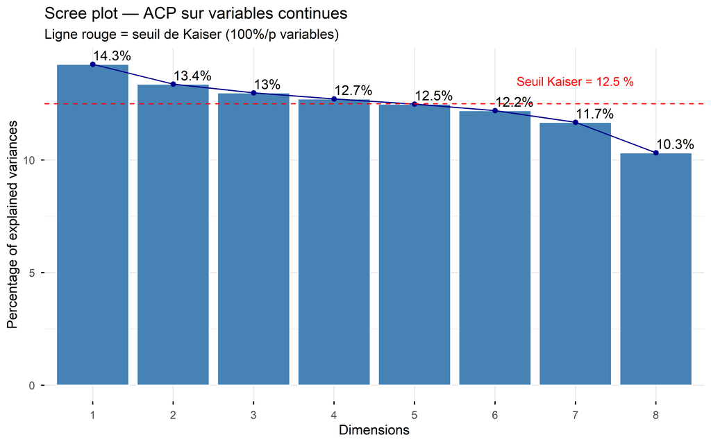

Figure 39: Q3 — Scree plot (éboulis des valeurs propres) avec ligne de Kaiser (λ=1)

```r
fviz_screeplot(res_pca, addlabels = TRUE, ncp = 8, barfill = "steelblue",
               barcolor = "white", linecolor = "darkblue") +
  geom_hline(yintercept = 100/p_acp, linetype = "dashed", color = "red") +
  annotate("text", x = 7, y = 100/p_acp + 1,
           label = sprintf("Seuil Kaiser = %.1f %%", 100/p_acp),
           color = "red", size = 3.5) +
  labs(title = "Scree plot — ACP sur variables continues",
       subtitle = "Ligne rouge = seuil de Kaiser (100%/p variables)")
```

> **Correction** : La ligne rouge représente le seuil de Kaiser exprimé en pourcentage de variance (100/p = 12.5 % pour 8 variables). Les axes au-dessus de ce seuil sont retenus. Le “coude” dans le scree plot indique le point où l’information marginal par axe devient négligeable.

### 7.1.4 Q4 — Cercle des corrélations et biplot

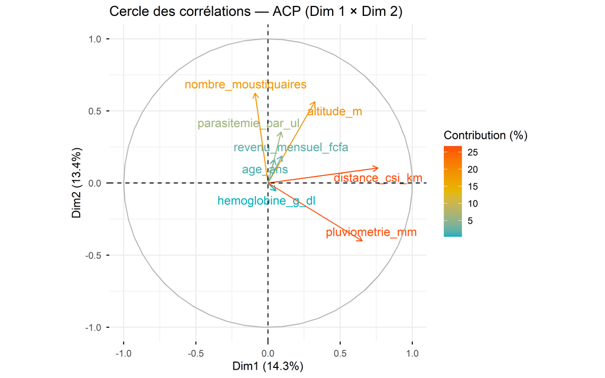

Figure 40: Q4a — Cercle des corrélations (contributions des variables aux axes 1 et 2)

```r
fviz_pca_var(res_pca,
             col.var   = "contrib",
             gradient.cols = c("#00AFBB", "#E7B800", "#FC4E07"),
             repel     = TRUE,
             title     = "Cercle des corrélations — ACP (Dim 1 × Dim 2)") +
  labs(color = "Contribution (%)")
```

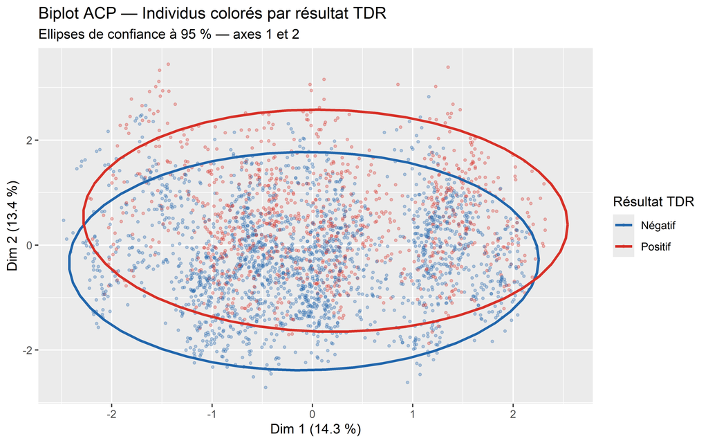

Figure 41: Q4b — Biplot ACP : individus colorés par résultat TDR

```r
# Extraire les scores des individus
scores_acp <- as.data.frame(res_pca$ind$coord[, 1:2]) |>
  mutate(TDR = paludisme_final$resultat_tdr)

ggplot(scores_acp, aes(x = Dim.1, y = Dim.2, color = TDR)) +
  geom_point(alpha = 0.3, size = 0.8) +
  stat_ellipse(level = 0.95, linewidth = 1) +
  scale_color_manual(values = c("Positif" = "#d73027", "Négatif" = "#2166ac")) +
  labs(
    title    = "Biplot ACP — Individus colorés par résultat TDR",
    subtitle = "Ellipses de confiance à 95 % — axes 1 et 2",
    x        = sprintf("Dim 1 (%.1f %%)", res_pca$eig[1, 2]),
    y        = sprintf("Dim 2 (%.1f %%)", res_pca$eig[2, 2]),
    color    = "Résultat TDR"
  )
```

> **Correction** : Le cercle des corrélations montre les variables les mieux représentées (proche du bord) et leurs corrélations mutuelles (vecteurs proches = corrélés positivement). Le biplot individus colorés par TDR permet de visualiser si les TDR+ se séparent des TDR- dans l’espace ACP. Le chevauchement complet des ellipses confirme l’absence de structure séparant les cas des non-cas dans l’espace socio-environnemental — cohérent avec les AUC ≈ 0.50 en D5.

## 7.2 Clustering non supervisé

### 7.2.1 Q5 — Détermination du nombre optimal de clusters

Deux méthodes complémentaires sont utilisées : la **méthode du coude** (WSS = Within Sum of Squares) et la **méthode silhouette** (cohésion vs séparation inter-cluster).

```r
# Utiliser les 3 premiers axes ACP pour réduire le bruit
scores_3d <- res_pca$ind$coord[, 1:3]

set.seed(3142)

# WSS (méthode du coude)
wss_vals <- sapply(1:8, function(k) {
  kmeans(scores_3d, centers = k, nstart = 25, iter.max = 100)$tot.withinss
})

# Silhouette
sil_vals <- sapply(2:8, function(k) {
  km  <- kmeans(scores_3d, centers = k, nstart = 25, iter.max = 100)
  mean(cluster::silhouette(km$cluster, dist(scores_3d))[, 3])
})

k_opt <- which.max(sil_vals) + 1
cat(sprintf("k optimal (silhouette max = %.4f) : k = %d\n", max(sil_vals), k_opt))
```

```
k optimal (silhouette max = 0.2631) : k = 4
```

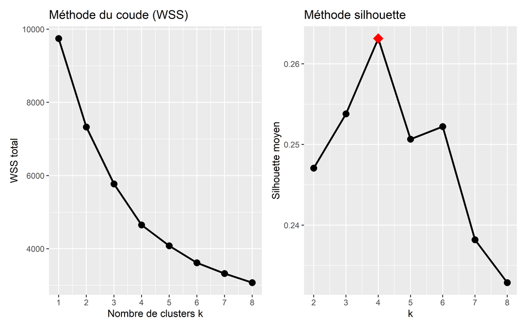

Figure 42: Q5 — Méthode du coude et silhouette pour k optimal (ACP Dim 1–3)

```r
p_wss <- tibble(k = 1:8, WSS = wss_vals) |>
  ggplot(aes(x = k, y = WSS)) +
  geom_line(linewidth = 1) + geom_point(size = 3) +
  scale_x_continuous(breaks = 1:8) +
  labs(title = "Méthode du coude (WSS)", x = "Nombre de clusters k", y = "WSS total")

p_sil <- tibble(k = 2:8, Silhouette = sil_vals) |>
  ggplot(aes(x = k, y = Silhouette)) +
  geom_line(linewidth = 1) + geom_point(size = 3) +
  geom_point(data = tibble(k = k_opt, Silhouette = max(sil_vals)),
             color = "red", size = 5, shape = 18) +
  scale_x_continuous(breaks = 2:8) +
  labs(title = "Méthode silhouette", x = "k", y = "Silhouette moyen")

p_wss + p_sil
```

> **Correction** : Le silhouette moyen mesure à quel point chaque individu ressemble mieux à son propre cluster qu’aux autres (plage : −1 à +1). Une valeur > 0.5 indique une structure forte ; 0.25–0.5, structure modérée. Sur données synthétiques, des valeurs autour de 0.25 indiquent une **structure faible mais détectable**. Le point rouge indique le k optimal retenu.

### 7.2.2 Q6 — K-means sur les scores ACP

```r
set.seed(3142)
km_final <- kmeans(scores_3d, centers = k_opt, nstart = 50, iter.max = 200)

cat(sprintf("K-means (k=%d) — Inertie intra : %.2f / Inertie totale : %.2f\n",
            k_opt, km_final$tot.withinss, km_final$totss))
```

```
K-means (k=4) — Inertie intra : 4652.38 / Inertie totale : 9745.18
```

```r
cat(sprintf("Variance expliquée entre groupes : %.1f %%\n",
            km_final$betweenss / km_final$totss * 100))
```

```
Variance expliquée entre groupes : 52.3 %
```

```r
cat("\nEffectifs par cluster :\n"); print(table(km_final$cluster))
```

```
Effectifs par cluster :
```

```
  1   2   3   4
606 755 806 833
```

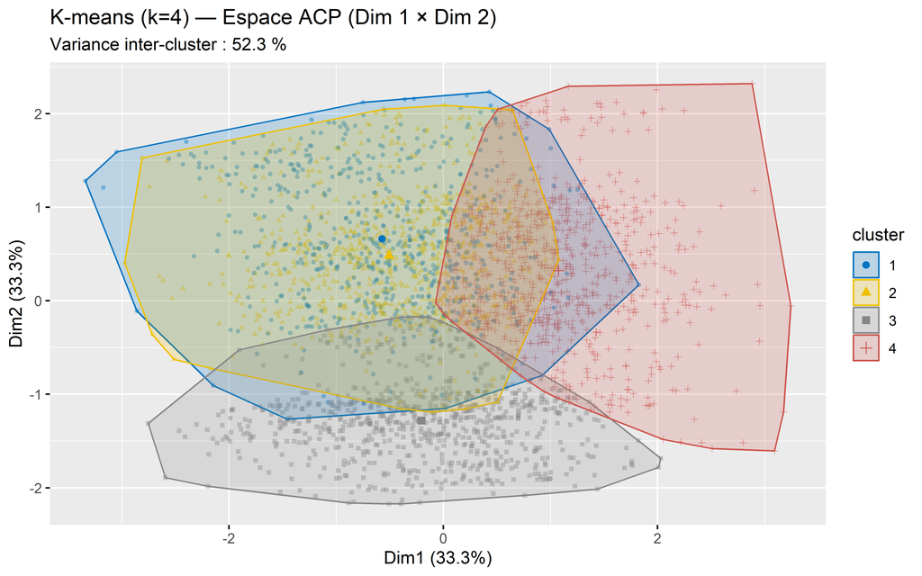

Figure 43: Q6 — K-means (k optimal) dans l’espace ACP (Dim 1 × Dim 2)

```r
fviz_cluster(km_final, data = scores_3d,
             geom = "point", alpha = 0.4, ellipse.type = "convex",
             palette = "jco", pointsize = 1) +
  labs(title = sprintf("K-means (k=%d) — Espace ACP (Dim 1 × Dim 2)", k_opt),
       subtitle = sprintf("Variance inter-cluster : %.1f %%",
                          km_final$betweenss / km_final$totss * 100))
```

### 7.2.3 Q7 — Classification ascendante hiérarchique (CAH) et dendrogramme

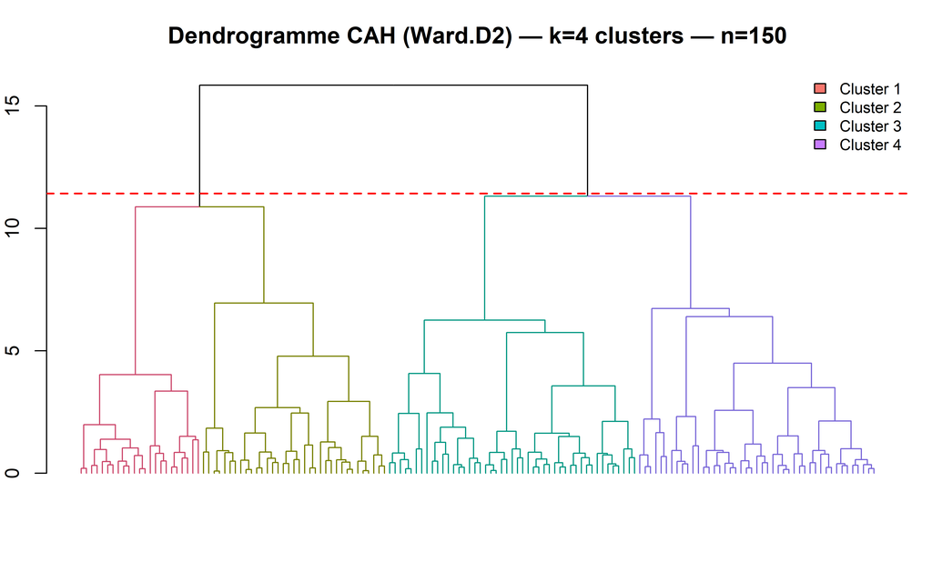

Figure 44: Q7 — Dendrogramme CAH (méthode de Ward) — sous-échantillon illustratif

```r
# Sous-échantillon pour la lisibilité du dendrogramme
set.seed(3142)
idx_dend <- sample(nrow(scores_3d), 150)
dist_mat  <- dist(scores_3d[idx_dend, ], method = "euclidean")
hc_ward   <- hclust(dist_mat, method = "ward.D2")

dend_obj <- as.dendrogram(hc_ward) |>
  color_branches(k = k_opt)

par(mar = c(4, 2, 3, 1))
plot(dend_obj, leaflab = "none", horiz = FALSE,
     main = sprintf("Dendrogramme CAH (Ward.D2) — k=%d clusters — n=150", k_opt),
     ylab = "Hauteur (distance de fusion)")
abline(h = rev(hc_ward$height)[k_opt - 1] * 1.05,
       col = "red", lty = 2, lwd = 1.5)
legend("topright", legend = paste("Cluster", 1:k_opt),
       fill = scales::hue_pal()(k_opt), bty = "n", cex = 0.8)
```

> **Correction** : La méthode de Ward minimise la variance intra-cluster à chaque fusion (critère de Ward.D2). La ligne rouge horizontale indique la coupure retenue pour k clusters. La hauteur de la dernière fusion avant coupure doit être nettement plus grande que les fusions précédentes — c’est le “saut” qui justifie k.

### 7.2.4 Q8 — Profil socio-épidémiologique des clusters

```r
# Associer les clusters aux données originales
profil_clusters <- paludisme_final |>
  slice(as.integer(names(km_final$cluster))) |>
  mutate(cluster = factor(km_final$cluster)) |>
  group_by(cluster) |>
  summarise(
    n                = n(),
    age_median       = round(median(age_ans, na.rm = TRUE), 1),
    hb_moyenne       = round(mean(hemoglobine_g_dl, na.rm = TRUE), 2),
    prev_tdr         = round(mean(resultat_tdr == "Positif") * 100, 1),
    prev_anemie      = round(mean(hemoglobine_g_dl < 11, na.rm = TRUE) * 100, 1),
    pct_rural        = round(mean(milieu == "Rural") * 100, 1),
    pct_pauvre       = round(mean(pauvre == "Oui") * 100, 1),
    revenu_median    = round(median(revenu_mensuel_fcfa, na.rm = TRUE)),
    dist_csi_median  = round(median(distance_csi_km, na.rm = TRUE), 1),
    .groups = "drop"
  )

profil_clusters
```

| cluster | n | age_median | hb_moyenne | prev_tdr | prev_anemie | pct_rural | pct_pauvre | revenu_median | dist_csi_median |
| --- | --- | --- | --- | --- | --- | --- | --- | --- | --- |
| 1 | 606 | 47 | 11.34 | 51.5 | 43.4 | 89.1 | 12.7 | 77666 | 9.0 |
| 2 | 755 | 52 | 12.77 | 21.6 | 15.5 | 90.7 | 32.2 | 61839 | 6.2 |
| 3 | 806 | 43 | 11.83 | 41.2 | 32.8 | 74.8 | 15.5 | 78402 | 20.3 |
| 4 | 833 | 22 | 10.36 | 26.5 | 64.1 | 92.7 | 10.9 | 84407 | 9.0 |

> **Correction** : Le profil des clusters traduit la **segmentation de la population** en groupes homogènes selon leurs caractéristiques socio-biologiques. Dans un programme de lutte contre le paludisme, ces clusters orientent le **ciblage des interventions** : les clusters avec forte prévalence TDR + forte pauvreté + éloignement du CSI reçoivent la priorité pour les distributions de MII et le déploiement d’ASC.

## 7.3 Factor Analysis of Mixed Data (FAMD)

### 7.3.1 Q9 — FAMD : variables numériques et catégorielles simultanément

La **FAMD** (Pagès, 2004) généralise l’ACP aux tableaux mixtes : elle standardise les variables quantitatives (comme l’ACP) et pondère les variables qualitatives (comme l’ACM), permettant une représentation unifiée de tous les types de variables.

```r
vars_famd_num <- c("age_ans", "hemoglobine_g_dl", "distance_csi_km",
                   "revenu_mensuel_fcfa", "nombre_moustiquaires")
vars_famd_cat <- c("sexe", "milieu", "resultat_tdr", "utilisation_MII",
                   "aspersion_intra_domiciliaire", "niveau_education", "pauvre")

df_famd <- paludisme_final |>
  select(all_of(c(vars_famd_num, vars_famd_cat))) |>
  mutate(across(all_of(vars_famd_cat), as.factor)) |>
  drop_na()

cat(sprintf("Dataset FAMD : %d individus × %d variables (%d numériques + %d catégorielles)\n",
            nrow(df_famd), ncol(df_famd), length(vars_famd_num), length(vars_famd_cat)))
```

```
Dataset FAMD : 3000 individus × 12 variables (5 numériques + 7 catégorielles)
```

```r
res_famd <- FAMD(df_famd, ncp = 5, graph = FALSE)

# Valeurs propres
eig_famd <- as.data.frame(res_famd$eig) |>
  tibble::rownames_to_column("Dim") |>
  rename(lambda = eigenvalue, pct_var = `percentage of variance`,
         pct_cum = `cumulative percentage of variance`) |>
  mutate(across(where(is.numeric), \(x) round(x, 3)))

cat("\nValeurs propres FAMD :\n")
```

```
Valeurs propres FAMD :
```

```r
print(eig_famd)
```

```
     Dim lambda pct_var pct_cum
1 comp 1  1.701  11.343  11.343
2 comp 2  1.238   8.250  19.594
3 comp 3  1.086   7.241  26.835
4 comp 4  1.063   7.087  33.922
5 comp 5  1.054   7.028  40.950
```

### 7.3.2 Q10 — Contributions des variables aux axes FAMD

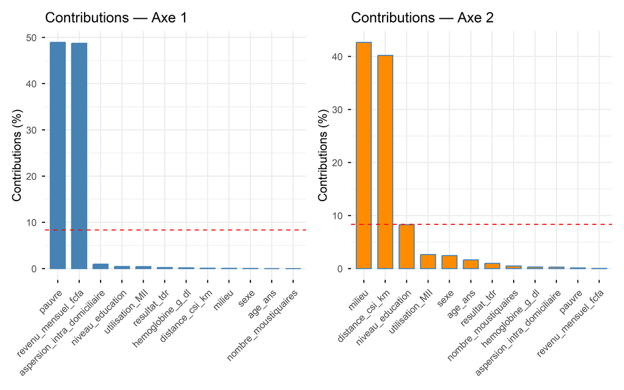

Figure 45: Q10 — Contributions des variables aux deux premiers axes FAMD

```r
p_var1 <- fviz_contrib(res_famd, choice = "var", axes = 1, top = 12,
                        fill = "steelblue") +
  labs(title = "Contributions — Axe 1") +
  theme(axis.text.x = element_text(angle = 45, hjust = 1))

p_var2 <- fviz_contrib(res_famd, choice = "var", axes = 2, top = 12,
                        fill = "darkorange") +
  labs(title = "Contributions — Axe 2") +
  theme(axis.text.x = element_text(angle = 45, hjust = 1))

p_var1 + p_var2
```

> **Correction** : Les contributions mesurent dans quelle proportion chaque variable (ou modalité) a construit l’axe. Une contribution élevée signifie que la variable est **structurante** pour cet axe. La ligne pointillée rouge indique la contribution attendue si toutes les variables contribuaient équitablement (100/p %). Une variable au-dessus de ce seuil est significativement représentée sur l’axe.

### 7.3.3 Q11 — Biplot FAMD : individus et variables dans un même espace

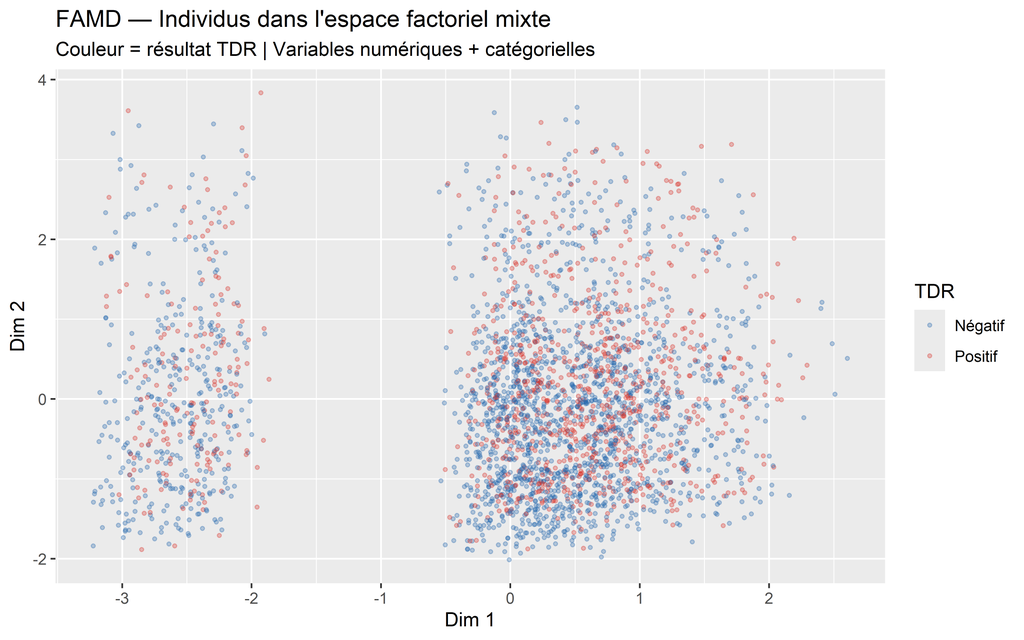

```r
 #| label: fig-d6-q11
 #| fig-cap: "Q11 — Biplot FAMD : individus colorés par résultat TDR (axes 1 × 2)"
coord_famd <- as.data.frame(res_famd$ind$coord)
coord_famd$TDR <- df_famd$resultat_tdr

ggplot(coord_famd, aes(x = Dim.1, y = Dim.2, color = TDR)) +
  geom_point(alpha = 0.3, size = 0.8) +
  scale_color_manual(values = c("Négatif" = "#2166ac", "Positif" = "#d73027")) +
  labs(title    = "FAMD — Individus dans l'espace factoriel mixte",
       subtitle = "Couleur = résultat TDR | Variables numériques + catégorielles",
       x = "Dim 1", y = "Dim 2", color = "TDR")
```

## 7.4 Analyse Factorielle des Correspondances (AFC)

### 7.4.1 Q12 — AFC sur tableau catégorie d’âge × charge parasitaire

L’**AFC** analyse les associations entre deux variables catégorielles à travers leur tableau de contingence. Elle décompose le χ² d’indépendance en axes factoriels, chaque axe expliquant une part de l’association totale.

```r
# Tableau de contingence catégorie_age × charge_parasitaire
tab_afc <- paludisme_final |>
  filter(!is.na(charge_parasitaire), !is.na(categorie_age)) |>
  with(table(categorie_age, charge_parasitaire))

cat("Tableau de contingence (categorie_age × charge_parasitaire) :\n")
```

```
Tableau de contingence (categorie_age × charge_parasitaire) :
```

```r
print(tab_afc)
```

```
             charge_parasitaire
categorie_age Élevée Faible Négatif
       enfant     31     31     122
       jeune      70     64     220
       adulte    206    226     877
       senior    206    194     753
```

```r
# Profils lignes (distributions de charge parasitaire par catégorie d'âge)
cat("\nProfils-lignes (%) :\n")
```

```
Profils-lignes (%) :
```

```r
round(prop.table(tab_afc, margin = 1) * 100, 1) |> print()
```

```
             charge_parasitaire
categorie_age Élevée Faible Négatif
       enfant   16.8   16.8    66.3
       jeune    19.8   18.1    62.1
       adulte   15.7   17.3    67.0
       senior   17.9   16.8    65.3
```

```r
# Test du χ² préalable à l'AFC
chi2_afc <- chisq.test(tab_afc)
cat(sprintf("\nTest χ² : χ²(%d) = %.2f,  p = %.4f\n",
            chi2_afc$parameter, chi2_afc$statistic, chi2_afc$p.value))
```

```
Test χ² : χ²(6) = 4.62,  p = 0.5927
```

```r
res_afc <- CA(tab_afc, graph = FALSE)
cat("\nValeurs propres AFC :\n")
```

```
Valeurs propres AFC :
```

```r
print(round(res_afc$eig, 4))
```

```
      eigenvalue percentage of variance cumulative percentage of variance
dim 1     0.0014                93.6919                           93.6919
dim 2     0.0001                 6.3081                          100.0000
```

```r
cat(sprintf("\nInertie totale (χ²/n) = %.6f\n",
            sum(res_afc$eig[, 1])))
```

```
Inertie totale (χ²/n) = 0.001542
```

> **Correction** : L’inertie totale de l’AFC = χ²/n. Elle mesure le degré d’association entre les deux variables : plus l’inertie est grande, plus les profils-lignes s’éloignent du profil moyen. La décomposition en axes (Dim1, Dim2…) décompose cette inertie : Dim1 explique la part maximale. Sur données synthétiques, l’inertie proche de 0 confirme l’absence d’association forte — cohérent avec les tests du χ² non significatifs des Devoirs 2 et 3.

### 7.4.2 Q13 — Biplot AFC : modalités dans l’espace factoriel

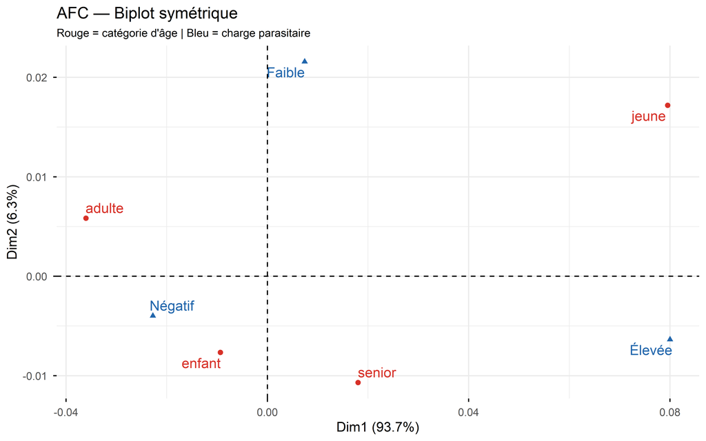

Figure 46: Q13 — Biplot AFC : catégorie d’âge × charge parasitaire (symétrique)

```r
fviz_ca_biplot(res_afc,
               repel      = TRUE,
               col.row    = "#d73027",
               col.col    = "#2166ac",
               arrow.fill = "grey70") +
  labs(title    = "AFC — Biplot symétrique",
       subtitle = "Rouge = catégorie d'âge | Bleu = charge parasitaire") +
  theme(plot.subtitle = element_text(size = 9))
```

> **Correction** : Dans le **biplot symétrique** de l’AFC, la proximité entre une modalité-ligne (rouge) et une modalité-colonne (bleu) indique une **co-occurrence** : cette catégorie d’âge est sur-représentée avec cette charge parasitaire. Des modalités éloignées du centre ont des profils atypiques. Des modalités proches du centre ont des profils proches du profil moyen général.

## 7.5 Analyse Factorielle des Correspondances Multiples (ACM)

### 7.5.1 Q14 — ACM sur variables catégorielles clés

L’**ACM** (Multiple Correspondence Analysis) généralise l’AFC à plus de deux variables catégorielles simultanément. Elle révèle les associations entre **modalités de plusieurs variables** dans un seul espace factoriel.

```r
vars_acm <- c("sexe", "milieu", "resultat_tdr", "utilisation_MII",
              "aspersion_intra_domiciliaire", "anemie", "pauvre", "categorie_age")

df_acm <- paludisme_final |>
  select(all_of(vars_acm)) |>
  mutate(across(everything(), as.factor)) |>
  drop_na()

cat(sprintf("Dataset ACM : %d individus × %d variables\n",
            nrow(df_acm), ncol(df_acm)))
```

```
Dataset ACM : 3000 individus × 8 variables
```

```r
cat("Modalités totales :", sum(sapply(df_acm, nlevels)), "\n\n")
```

```
Modalités totales : 19
```

```r
res_acm <- MCA(df_acm, ncp = 5, graph = FALSE)

# Valeurs propres et variance expliquée
eig_acm <- as.data.frame(res_acm$eig) |>
  tibble::rownames_to_column("Dim") |>
  rename(lambda=eigenvalue, pct=`percentage of variance`,
         cum=`cumulative percentage of variance`) |>
  mutate(across(where(is.numeric), \(x) round(x, 3)))

# Taux d'inertie corrigé (formule de Benzécri)
p_var_acm <- length(vars_acm)
k_benzecri <- sum(res_acm$eig[, 1] > 1/p_var_acm)
cat(sprintf("Axes retenus (λ > 1/p = %.3f) : %d\n", 1/p_var_acm, k_benzecri))
```

```
Axes retenus (λ > 1/p = 0.125) : 5
```

```r
cat("\nValeurs propres ACM (5 premiers axes) :\n")
```

```
Valeurs propres ACM (5 premiers axes) :
```

```r
print(head(eig_acm, 5))
```

```
    Dim lambda   pct    cum
1 dim 1  0.136 9.880  9.880
2 dim 2  0.135 9.786 19.666
3 dim 3  0.134 9.723 29.388
4 dim 4  0.130 9.463 38.851
5 dim 5  0.126 9.178 48.029
```

> **Correction — particularité de l’ACM** : les valeurs propres de l’ACM sont systématiquement faibles car chaque variable binaire contribue peu individuellement. Le seuil de Kaiser pour l’ACM est λ > 1/p (où p = nombre de variables), non λ > 1. La **correction de Benzécri** recalibre les taux de variance pour être comparables à l’AFC.

### 7.5.2 Q15 — Graphique des modalités ACM

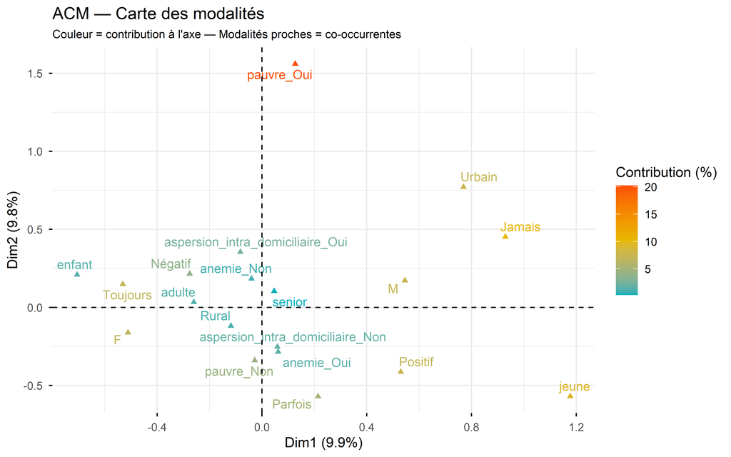

Figure 47: Q15 — ACM : carte des modalités (variables catégorielles) — axes 1 et 2

```r
fviz_mca_var(res_acm,
             repel         = TRUE,
             col.var       = "contrib",
             gradient.cols = c("#00AFBB", "#E7B800", "#FC4E07"),
             labelsize     = 3.5) +
  labs(title    = "ACM — Carte des modalités",
       subtitle = "Couleur = contribution à l'axe — Modalités proches = co-occurrentes",
       color    = "Contribution (%)") +
  theme(plot.subtitle = element_text(size = 9))
```

> **Correction** : Deux modalités proches sur la carte ACM **co-occurrent** fréquemment chez les mêmes individus. Les modalités éloignées du centre sont rares ou spécifiques à un sous-groupe. Les modalités proches du centre ont une distribution homogène dans l’échantillon. La couleur indique la contribution à la construction de l’axe (rouge = forte contribution).

### 7.5.3 Q16 — Classification sur scores ACM (HCPC)

La **HCPC** (*Hierarchical Clustering on Principal Components*) combine la CAH avec les résultats de l’ACM pour identifier des **classes d’individus** basées sur leurs profils de réponses aux variables catégorielles.

```r
set.seed(3142)
res_hcpc <- HCPC(res_acm, nb.clust = 3, graph = FALSE)

cat("Distribution des classes HCPC :\n")
```

```
Distribution des classes HCPC :
```

```r
print(table(res_hcpc$data.clust$clust))
```

```
   1    2    3
1122 1264  614
```

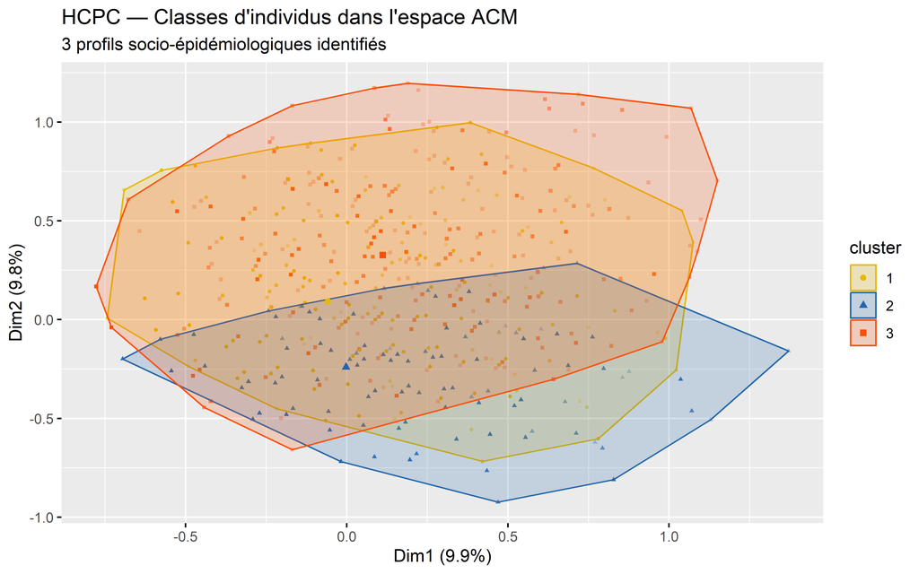

Figure 48: Q16 — HCPC sur ACM : classification des individus en 3 profils

```r
# Profil des classes par les variables actives
fviz_cluster(res_hcpc,
             geom       = "point",
             ellipse.type = "convex",
             palette    = c("#E7B800", "#2166ac", "#FC4E07"),
             alpha      = 0.3,
             pointsize  = 0.8) +
  labs(title    = "HCPC — Classes d'individus dans l'espace ACM",
       subtitle = "3 profils socio-épidémiologiques identifiés")
```

```r
# Variables les plus discriminantes des classes (v-test > 1.96)
cat("=== Variables caractérisant les classes HCPC ===\n")
```

```
=== Variables caractérisant les classes HCPC ===
```

```r
desc_cl <- res_hcpc$desc.clust$test.chi2
if (!is.null(desc_cl)) {
  cat("Test χ² d'association classe × variable :\n")
  tibble::rownames_to_column(as.data.frame(desc_cl), "Variable") |>
    mutate(across(where(is.numeric), \(x) round(x, 4))) |>
    arrange(p.value) |>
    print()
}

# Prévalence TDR par classe HCPC
paludisme_final |>
  slice(seq_len(nrow(res_hcpc$data.clust))) |>
  mutate(classe_hcpc = res_hcpc$data.clust$clust) |>
  group_by(classe_hcpc) |>
  summarise(
    n          = n(),
    prev_tdr   = round(mean(resultat_tdr == "Positif") * 100, 1),
    prev_anemie= round(mean(hemoglobine_g_dl < 11, na.rm = TRUE) * 100, 1),
    pct_rural  = round(mean(milieu == "Rural") * 100, 1),
    pct_pauvre = round(mean(pauvre == "Oui") * 100, 1),
    .groups = "drop"
  )
```

| classe_hcpc | n | prev_tdr | prev_anemie | pct_rural | pct_pauvre |
| --- | --- | --- | --- | --- | --- |
| 1 | 1122 | 33.1 | 49.3 | 96.7 | 21.4 |
| 2 | 1264 | 33.2 | 42.2 | 95.3 | 0.0 |
| 3 | 614 | 38.6 | 15.0 | 50.7 | 48.2 |

**NoteBilan — Devoir 6 (16 questions)**

| Section | Méthode | Questions | Objectif |
| --- | --- | --- | --- |
| A | ACP | Q1–Q4 | Réduction dimensionnelle sur variables continues ; identification des axes de variance |
| B | Clustering | Q5–Q8 | Segmentation de la population en profils homogènes (K-means + CAH) |
| C | FAMD | Q9–Q11 | Analyse simultanée de variables numériques et catégorielles |
| D | AFC | Q12–Q13 | Association entre deux variables catégorielles (profils-lignes/colonnes) |
| E | ACM + HCPC | Q14–Q16 | Structure latente des variables catégorielles ; classification typologique |

**Points clés** : standardisation obligatoire pour l’ACP ; test de Bartlett pour justifier l’ACP ; silhouette pour k optimal ; FAMD pour données mixtes ; AFC = χ² décomposé en axes ; ACM = AFC multi-variables ; HCPC = clustering sur composantes factorielles.